# Ritika’s Replication of ‘The development of sex differences in play in wild white‐faced capuchins (Cebus capucinus)’ By Sasha L. Winkler and Susan E. Perry

Ritika

2023-12-14

# Winkler Data

[video not shown]

## Introduction

In 2021, Sasha L. Winkler and Susan E. Perry published an article in the American Journal or Primatology studying sex differences in play in wild Capuchins. The study was important because it is one of the first longitudinal study of play behavior in any primate. The authors collected and compiled 18 years worth of data detailing the approximated age of a focal Capuchin along with the amount of social play, solitary play and grooming it engaged in. The authors used this data and ran a series of generalized linear mixed models, considering both linear and quadratic effects of age. From this, they were able to pick three optimal models for each of the three behavioral play types based on sex and age predictors.

For this replication assignment, I will be replicating three statistics.  
The first is a descriptive table showing the rate of play with different sexes.  
The second is an inferential statistic in which I run multiple glmm models and find the best ones to describe social play, solitary play and grooming.  
Finally, I replicate a figure showing the sex differences in solitary play behavior both with the actual data and the generated model. The authors found that ‘at no age do male and female solitary play rates show biologically meaningful differences from one another’.

## Install Packages

Let’s first load in all the packages needed!

```r
> library(formatR)
> library(openxlsx)
> library(curl)
> library(kableExtra)
> library(gridExtra)
> library(ggplot2)
> # To replicate the inferential glmm, I will use lme4.
> library(lme4)
> library(merTools)
> library(matrixStats)
```

## Descriptive Statistic

To begin, I will read in the first dataset provided by Winkler and Perry. Their excel file has 3 sheets, each with their own datasets. For our descriptive statistic I will be using data that covers what kinds of individuals (adult female, adult male, immature female, immature male) a focal plays with, found in the *Winkler_play_sex_dataset* sheet.

```r
> winkler_data <- read.xlsx("http://raw.githubusercontent.com/ritikasibal/rsibal-data-replication-assignment/main/Winkler_Perry_dataset_with_codebook.xlsx",
+     sheet = "Winkler_play_sex_dataset")
> head(winkler_data)
```

```
##   Subject Sex Age Mean.#.immature.males Mean.#.immature.females
## 1      CD   f   0                     7                       6
## 2      CD   f   1                     7                       9
## 3      CD   f   2                     5                       9
## 4      CD   f   3                     6                      10
## 5      CD   f   4                     6                      11
## 6      CD   f   5                     3                       4
##   Mean.#.adult.males Mean.#.adult.females
## 1                  7                    9
## 2                  7                   10
## 3                  9                   11
## 4                 10                   11
## 5                  9                   10
## 6                  4                    7
```

As you can see, this tibble shows us the distribution of interactions between individuals.

Next, in the supplementary information provided by the paper, the following table was given. For this first section, I will attempt to replicate this table and its statistics, which requires finding ratios for each focal type.

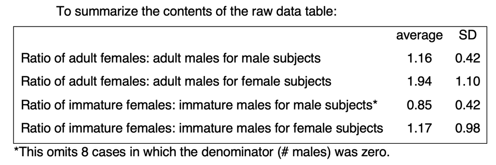

```r
> # Lets create a function to parse through our data and calculate the
> # ratios
> get_ratios <- function(var1, var2, focal, data) {
+     ratios <- c()
+     for (i in 1:nrow(data)) {
+         # check for the focal sex, and also that the denominator is not 0
+         # (based on what the authors did)
+         if (data[i, ]$Sex == focal && data[[i, var2]] != 0) {
+             ratios <- c(ratios, data[[i, var1]]/data[[i, var2]])
+         }
+     }
+     return(c(mean = mean(ratios), sd = sd(ratios)))
+ }
>
> # Ratio of adult females: adult males for male subjects
> desc_1 <- get_ratios("Mean.#.adult.females", "Mean.#.adult.males", "m", winkler_data)
>
> # Ratio of adult females: adult males for female subjects
> desc_2 <- get_ratios("Mean.#.adult.females", "Mean.#.adult.males", "f", winkler_data)
>
> # Ratio of immature females: immature males for male subjects
> desc_3 <- get_ratios("Mean.#.immature.females", "Mean.#.immature.males", "m",
+     winkler_data)
>
> # Ratio of immature females: immature males for female subjects
> desc_4 <- get_ratios("Mean.#.immature.females", "Mean.#.immature.males", "f",
+     winkler_data)
>
> # Create a single dataframe from all our ratio values
> df <- data.frame(Type = c("Ratio of adult females: adult males for male subjects",
+     "Ratio of adult females: adult males for female subjects", "Ratio of immature females: immature males for male subjects",
+     "Ratio of immature females: immature males for female subjects"), Mean = c(desc_1[1],
+     desc_2[1], desc_3[1], desc_4[1]), Sd = c(desc_1[2], desc_2[2], desc_3[2],
+     desc_4[2]))
>
> # Create a table from our data frame, save it in the /img directory
> knitr::kable(df, format = "html", digits = 2) %>%
+     kable_styling()
```

| Type | Mean | Sd |
| --- | --- | --- |
| Ratio of adult females: adult males for male subjects | 1.17 | 0.72 |
| Ratio of adult females: adult males for female subjects | 1.97 | 1.21 |
| Ratio of immature females: immature males for male subjects | 0.85 | 0.44 |
| Ratio of immature females: immature males for female subjects | 1.20 | 1.11 |

My calculated values are slightly different to the ones given by the authors in the supplementary information. Initially, I was not sure if this was an error on my part. However, after combing through my logic, I also double checked the values using excels inbuilt average() and sd() functions and found the same values as what I had calculated in my script. These differences are not huge, so it is likely the authors either omitted more outliers for their calculation (based on judgement calls or other criteria) or simply did not give us access to the actual values they used for their calculation.

Additionally, the authors disclosed that they chose to omit values where the denominator of the ratio was 0. I think this omission might not be best practice. Alternatively, the authors could have added 1 to each value (so there are no more zeros) and then remove 1 from the end (after ratios, mean and sd are calculated) to standardize and re-balance the data. This would prevent any need for omission.

## Inferential Statistic

First, I will read in the dataset.

```r
> winkler_data <- read.xlsx("http://raw.githubusercontent.com/ritikasibal/rsibal-data-replication-assignment/main/Winkler_Perry_dataset_with_codebook.xlsx",
+     sheet = "Winkler_Perry_dataset")
> head(winkler_data)
```

```
##   focal sex Natal_group year total sm  sp wp avggroupsize
## 1    AH   m          FF    0  1722 22  54 38      33.8214
## 2    AH   m          FF    1  1828 43 112 19      35.5929
## 3    AH   m          FF    2   464  7  15  0      38.7137
## 4    CA   m          AA    1  1026 25  51  5      35.6113
## 5    CA   m          AA    2  1784 42  47  0      34.0123
## 6    CA   m          AA    3  2441 39 110  4      17.1962
```

The authors used a few non intuitive abbreviations to code their data. For the sake of convince, I will print out there code book here

```r
> knitr::kable(read.xlsx("http://raw.githubusercontent.com/ritikasibal/rsibal-data-replication-assignment/main/Winkler_Perry_dataset_with_codebook.xlsx",
+     sheet = "codebook"))
```

[output not shown]

‘To determine sex differences in the rates of each behavior and how they change over the lifespan’, the authors ran a series of generalized linear mixed models, with **outcome variables**=*social play, solitary play, and grooming*, **predictor variables**=*sex, age, and the interaction between sex and age* and **random effect**=*individual* which accounted for repeated sampling for each individual over time. I will attempt to do the same!

The authors disclosed that they found that a ‘negative binomial provided the best fit for social play, solitary play and grooming’. Let’s see if we find the same thing.

```r
> # SOCIAL PLAY Use .nb for negative binomial glmm
> sp_model1 <- glmer.nb(formula = sp ~ year + sex + year * sex + (1 | focal),
+     data = winkler_data)
> # Poisson Model
> sp_model2 <- glmer(formula = sp ~ year + sex + year * sex + (1 | focal), data = winkler_data,
+     family = "poisson")
> # Create dataframe from AIC and BIC values
> df1 <- data.frame(Model_Type = c("negative binomial", "poisson"), AIC = c(summary(sp_model1)$AIC[1],
+     summary(sp_model2)$AIC[1]), BIC = c(summary(sp_model1)$AIC[2], summary(sp_model2)$AIC[2]))
>
> # GROOMING Use .nb for negative binomial glmm
> sm_model1 <- glmer.nb(formula = sm ~ year + sex + year * sex + (1 | focal),
+     data = winkler_data)
> # Poisson Model
> sm_model2 <- glmer(formula = sm ~ year + sex + year * sex + (1 | focal), data = winkler_data,
+     family = "poisson")
> # Create dataframe from AIC and BIC values
> df2 <- data.frame(Model_Type = c("negative binomial", "poisson"), AIC = c(summary(sm_model1)$AIC[1],
+     summary(sm_model2)$AIC[1]), BIC = c(summary(sm_model1)$AIC[2], summary(sm_model2)$AIC[2]))
>
> # SOLITARY PLAY Use .nb for negative binomial glmm
> wp_model1 <- glmer.nb(formula = wp ~ year + sex + year * sex + (1 | focal),
+     data = winkler_data)
> # Poisson Model
> wp_model2 <- glmer(formula = wp ~ year + sex + year * sex + (1 | focal), data = winkler_data,
+     family = "poisson")
> # Create dataframe from AIC and BIC values
> df3 <- data.frame(Model_Type = c("negative binomial", "poisson"), AIC = c(summary(wp_model1)$AIC[1],
+     summary(wp_model2)$AIC[1]), BIC = c(summary(wp_model1)$AIC[2], summary(wp_model2)$AIC[2]))
```

Social Play Models

| Model_Type | AIC | BIC |
| --- | --- | --- |
| negative binomial | 2500.159 | 2524.138 |
| poisson | 5051.615 | 5071.597 |

Grooming Models

| Model_Type | AIC | BIC |
| --- | --- | --- |
| negative binomial | 3464.874 | 3488.853 |
| poisson | 8059.168 | 8079.150 |

Solitary Play Models

| Model_Type | AIC | BIC |
| --- | --- | --- |
| negative binomial | 1209.304 | 1233.283 |
| poisson | 1532.492 | 1552.475 |

Comparing the AIC and BIC values for all three outcome variables of *social play, solitary play, and grooming* we see that the AIC and BIC values for all three are lower in the negative binomial model, meaning that it is a better fit. This is consistent with what the authors found! A negative binomial model accounts for a variance of the data is higher than the mean.

For fun, I wanted to see how the created model would hold up against real data for time spent social playing. To do this I used the simulate() function that we learned about in class. I then plotted the simulated data against the real values collected from the field.

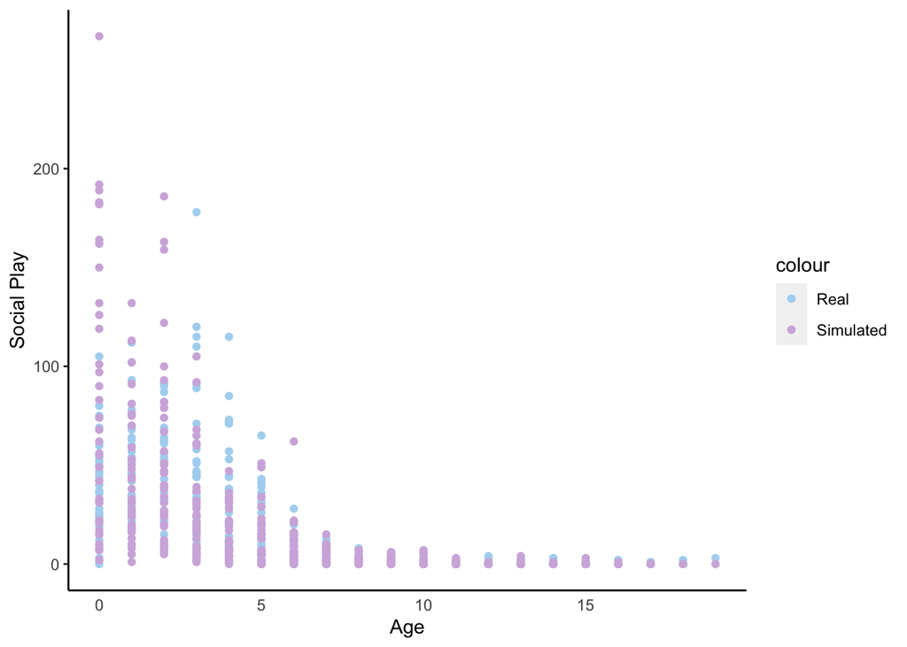

```r
> # We are simulating so lets set the seed
> set.seed(4)
> # Found this here:
> # https://cran.r-project.org/web/packages/glmmTMB/vignettes/sim.html
> ss_simlm <- transform(winkler_data, Reaction = simulate(sp_model1)[[1]])
>
> # Copy the data so we can still use the original dataset later
> winkler_data_copy <- winkler_data
> # Add the simulated data into the dataset copy
> winkler_data_copy$simulated <- ss_simlm$Reaction
> # Plot! Year on X and Real vs Simulated on Y
> ggplot(winkler_data_copy, aes(x = year)) + geom_point(aes(y = sp, color = "Real")) +
+     geom_point(aes(y = simulated, color = "Simulated")) + scale_colour_manual(values = c("#aed6f1",
+     "#D2B4DE")) + theme(axis.ticks.x = element_blank(), panel.border = element_blank(),
+     panel.grid.major = element_blank(), panel.grid.minor = element_blank(),
+     axis.line = element_line(colour = "black"), panel.background = element_blank()) +
+     ylab("Social Play") + xlab("Age")
```

Over all our model looks pretty great, it follows the trend of the original data quite well!

## Figure Statistic

I choose to replicate the solitary play figure because, based on the papers findings, it was the only model that did not use a quadratic predictor variable. This way, I was able to use the models based on my analysis in the previous section. Because of this however, I plotted the frequency of solitary play instead of the ratio of solitary play to total observations, as getting a good predictor total observation value would have required generating many more glmm models. The graph shows the same trend as seen in the paper.

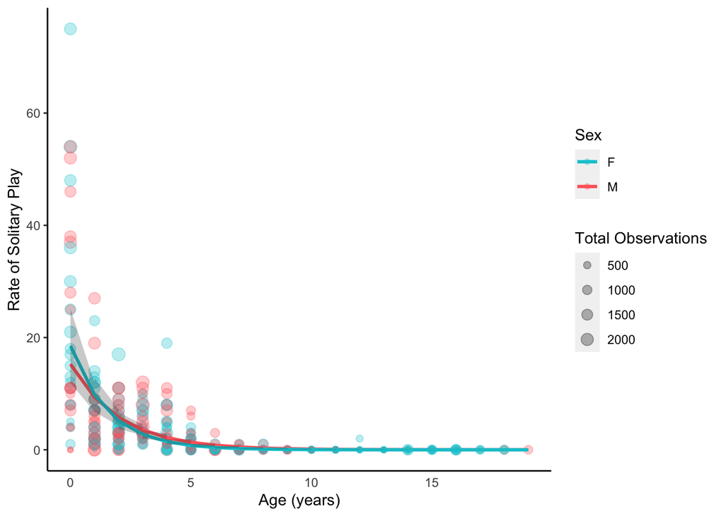

```r
> # Create a data frame for the predictor varibales
> pred_data = expand.grid(focal = "AH", sex = c("m", "f"), year = unique(winkler_data$year))
> # Predict! re.form=NA allows us to randomise for focal too
> pred_data$wp_pred <- predict(wp_model1, newdata = pred_data, type = "response",
+     re.form = NA)
>
> # This is needed to use bootMer
> temp_function <- function(glmm) {
+     predict(glmm, newdata = pred_data, re.form = NA, type = "response")
+ }
>
> # The authors used bootMer to calculate their confidence intervals so I
> # chose to use that too.
> bt <- bootMer(wp_model1, temp_function, nsim = 100, re.form = NA)
> std_err <- colSds(bt$t)
> pred_data$lwr <- pred_data$wp_pred - std_err * 1.96
> pred_data$upr <- pred_data$wp_pred + std_err * 1.96
>
> # Plot! Year on X axis and Play on Y Used https://www.color-hex.com to
> # find the exact colors!  size = total in geom_point will change the
> # points to reflect the total observations
> ggplot() + geom_point(data = winkler_data, aes(x = year, y = wp, color = sex,
+     size = total), alpha = 0.3) + scale_size(name = "Total Observations", range = c(0.5,
+     4)) + theme(axis.ticks.x = element_blank(), panel.border = element_blank(),
+     panel.grid.major = element_blank(), panel.grid.minor = element_blank(),
+     axis.line = element_line(colour = "black"), panel.background = element_blank()) +
+     ylab("Rate of Solitary Play") + xlab("Age (years)") + geom_line(data = pred_data,
+     aes(x = year, y = wp_pred, colour = sex), size = 1.1) + scale_colour_manual(values = c("#00c8d3",
+     "#ff686b"), labels = c("F", "M"), name = "Sex") + geom_ribbon(data = pred_data,
+     aes(x = year, ymin = lwr, ymax = upr), alpha = 0.25, linetype = 0)
```

And here is the original figure to compare!

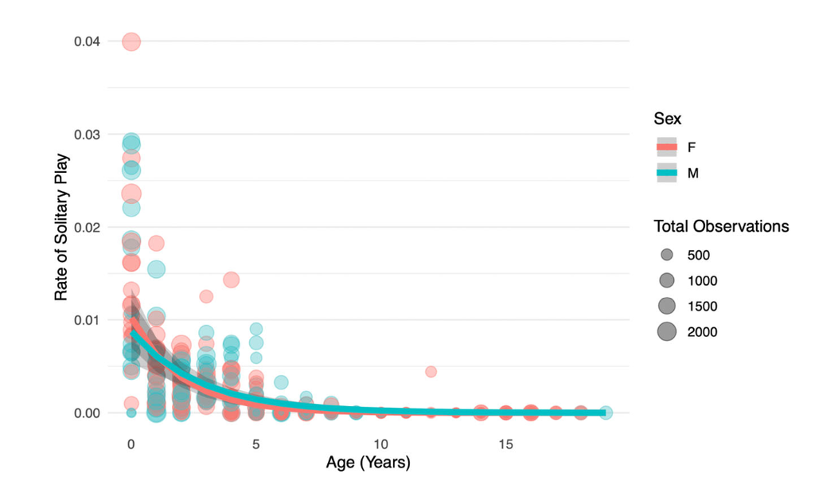

# Knott Data

[video not shown]

## Introduction

As I have some coding experience, to challenge myself for this assignment I not only replicated figures but decided to conduct my own statistical analysis. As glmms are a very new concept for me, I thought that trying to use them would be a welcome challenge!

Since I am a part of Dr. Cheryl Knott’s lab, I asked her whether there was any longitudinal data that I could take a look at. For my thesis, I will broadly be focued on characterising orangutan locomotion through pose estimation, so for this analysis Dr. Knott thought it would be beneficial to study the ontogeny of locomotion in the Bornean Orangutan. Dr. Knott had a 20 year data set characterising oranguatan Age, Body Position, Tree Position, Tree Height, Act type along with Pheno data (where act type is a description of the locomotion data (e.g. Eat)). For this analysis, I wanted to see if there was a good way to predict Act type in relation to Age, with the prediction that infant and juvenile orangutans have a wider array of postures ‘acting’ when compared to adults

To do this, I decided to compare three different model types:  
1. Neural Network  
2. randomForest  
3. MCMCglmm (Markov chain Monte Carlo glmm)  
With different predictor variables. The outcome variable (‘Act type’) of all these analysis will be multinomial and categorical.

## Install Packages

Let’s begin by installing all required packages again!

```r
> library(openxlsx)
> library(rsample)
> library(randomForest)
> library(dplyr)
> library(caret)
> library(nnet)
> library(MCMCglmm)
```

## Read in Data

Let’s read in the data and visualize what it actually looks like.

```r
> knott_data <- read.xlsx("http://raw.githubusercontent.com/ritikasibal/rsibal-data-replication-assignment/main/OntogenyOfLocomotion.xlsx")
> head(knott_data)
```

```
##   Follow  Date   Name Minutes         Sex      Age PhenoSum PhenoNum  Act
## 1    707 35094 Eminel     378 Adol Female 8.671233        L    58788  Eat
## 2    707 35094 Eminel     378 Adol Female 8.671233        L    58788  Eat
## 3    707 35094 Eminel     378 Adol Female 8.671233        L    58788 Rest
## 4    707 35094 Eminel     378 Adol Female 8.671233        L    58788 Rest
## 5    707 35094 Eminel     378 Adol Female 8.671233        L    58788 Rest
## 6    707 35094 Eminel     378 Adol Female 8.671233        L    58788 Rest
##        BP     TP   Height    AvgMin Bouts    Percent TotalMin
## 1    Hang Branch 22.00000 12.000000     1 0.03174603     12.0
## 2     Sit Branch 19.25000 11.250000     4 0.11904762     45.0
## 3 LieDown Branch       NA 27.500000     2 0.14550265     55.0
## 4    Quad Branch 25.00000  7.000000     1 0.01851852      7.0
## 5     Sit Branch 22.41509  7.229167    24 0.45899471    173.5
## 6     Sit  Liana 18.50000  3.000000     2 0.01587302      6.0
```

```r
> # We will remove the 'CariRayap' act type as it is too specific and can be
> # placed under 'Travel'
> knott_data <- knott_data[!grepl("CariRayap", knott_data$Act), ]
> # Omit all NAs
> knott_data <- na.omit(knott_data)
```

## Descriptive Statistic

Great! Now that we know what the data looks like, lets do a preliminary visualization of the act differences between infant and adult orangutans. To do this, I will filter the data for infant (less than 5 years) and adults (more than 14 years) and look at the differences in rate of locomotion

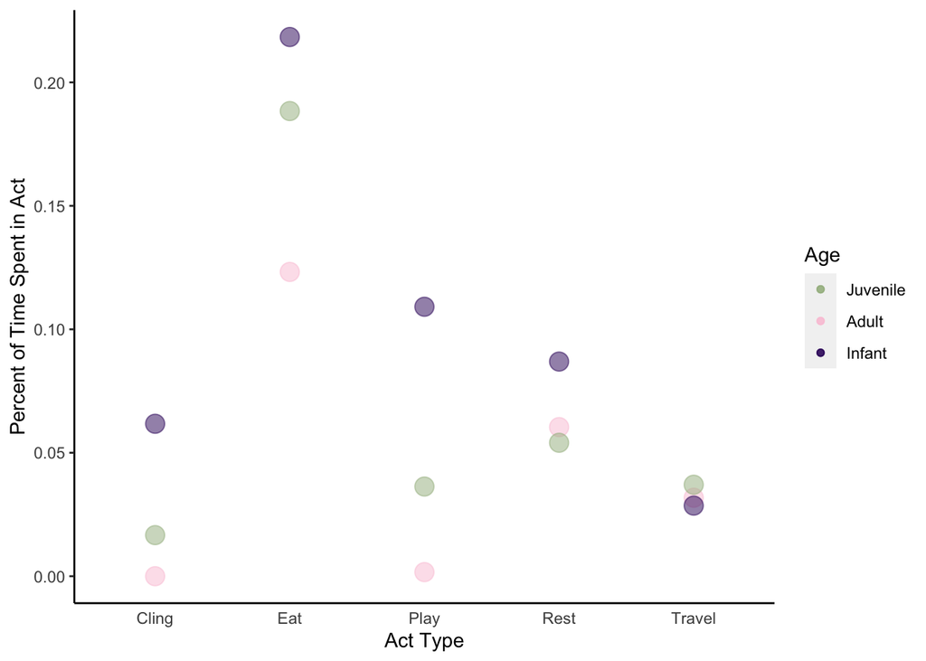

```r
> IandA_df <- data.frame(Act = unique(knott_data$Act))
> # Infant age: up to 5
> infant <- knott_data[knott_data$Age < 5, ]
> eat_i <- sum(infant[infant$Act == "Eat", "Percent"])/NROW(infant[infant$Act ==
+     "Eat", "Percent"])
> rest_i <- sum(infant[infant$Act == "Rest", "Percent"])/NROW(infant[infant$Act ==
+     "Rest", "Percent"])
> travel_i <- sum(infant[infant$Act == "Travel", "Percent"])/NROW(infant[infant$Act ==
+     "Travel", "Percent"])
> play_i <- sum(infant[infant$Act == "Play", "Percent"])/NROW(infant[infant$Act ==
+     "Play", "Percent"])
> cling_i <- sum(infant[infant$Act == "Cling", "Percent"])/NROW(infant[infant$Act ==
+     "Cling", "Percent"])
> IandA_df$Infant <- c(eat_i, rest_i, travel_i, play_i, cling_i)
> IandA_df$Infant[is.nan(IandA_df$Infant)] <- 0
>
> # Juvenile age: 5-14
> juv <- knott_data[(knott_data$Age > 5) & (knott_data$Age < 14), ]
> eat_j <- sum(juv[juv$Act == "Eat", "Percent"])/NROW(juv[juv$Act == "Eat", "Percent"])
> rest_j <- sum(juv[juv$Act == "Rest", "Percent"])/NROW(juv[juv$Act == "Rest",
+     "Percent"])
> travel_j <- sum(juv[juv$Act == "Travel", "Percent"])/NROW(juv[juv$Act == "Travel",
+     "Percent"])
> play_j <- sum(juv[juv$Act == "Play", "Percent"])/NROW(juv[juv$Act == "Play",
+     "Percent"])
> cling_j <- sum(juv[juv$Act == "Cling", "Percent"])/NROW(juv[juv$Act == "Cling",
+     "Percent"])
> IandA_df$Juvenile <- c(eat_j, rest_j, travel_j, play_j, cling_j)
> IandA_df$Juvenile[is.nan(IandA_df$Juvenile)] <- 0
>
> # Adult age: 14 and older
> adult <- knott_data[knott_data$Age >= 14, ]
> eat_a <- sum(adult[adult$Act == "Eat", "Percent"])/NROW(adult[adult$Act == "Eat",
+     "Percent"])
> rest_a <- sum(adult[adult$Act == "Rest", "Percent"])/NROW(adult[adult$Act ==
+     "Rest", "Percent"])
> travel_a <- sum(adult[adult$Act == "Travel", "Percent"])/NROW(adult[adult$Act ==
+     "Travel", "Percent"])
> play_a <- sum(adult[adult$Act == "Play", "Percent"])/NROW(adult[adult$Act ==
+     "Play", "Percent"])
> cling_a <- sum(adult[adult$Act == "Cling", "Percent"])/NROW(adult[adult$Act ==
+     "Cling", "Percent"])
> IandA_df$Adult <- c(eat_a, rest_a, travel_a, play_a, cling_a)
> IandA_df$Adult[is.nan(IandA_df$Adult)] <- 0
>
> ggplot() + geom_point(data = IandA_df, aes(x = Act, y = Adult, color = "#a1b88d",
+     label = Adult, size = 1), alpha = 0.5) + geom_point(data = IandA_df, aes(x = Act,
+     y = Infant, color = "#fac6d9", label = Infant, size = 1), alpha = 0.5) +
+     geom_point(data = IandA_df, aes(x = Act, y = Juvenile, color = "#330066",
+         label = Juvenile, size = 1), alpha = 0.5) + scale_colour_manual(values = c("#a1b88d",
+     "#fac6d9", "#330066"), labels = c("Juvenile", "Adult", "Infant"), name = "Age") +
+     theme(axis.ticks.x = element_blank(), panel.border = element_blank(), panel.grid.major = element_blank(),
+         panel.grid.minor = element_blank(), axis.line = element_line(colour = "black"),
+         panel.background = element_blank()) + ylab("Percent of Time Spent in Act") +
+     xlab("Act Type") + scale_size_continuous(guide = "none")
```

## Neural Networks and RandomForests

To attempt to predict Act type as an outcome, I will be running a neural network. For this, I choose predictor variables of Age, Body position (BP) and Tree Position (TP) as I thought they were the most likely to effect Act. Though I did not add this code here, I also tried predictor variables of PhenoNum, PhenoSum and Height but found that they worsened the model. I was also interested, personally, whether BP could also be characterised by Age and so ran a neural network for that as well.

I also wanted to see if other predictive models would be better suited to this type of analysis. To do that, I reran both the formulas with randomForest.

So, that gave me two questions:  
1. With BP, TP and Age, will we be able to predict what Act the focal individual is performing?  
2. With Age, Tree Height, TP, will we be able to predict the body position of the individual?

Lets find out!

```r
> # Set the seed again as we are random sampling
> set.seed(12345678)
>
> # Make the data into factors
> knott_data[sapply(knott_data, is.character)] <- lapply(knott_data[sapply(knott_data,
+     is.character)], as.factor)
>
> # 60% to train and 40% to test our models on!
> split_1 <- initial_split(knott_data, prop = 0.6)
> train_1 <- training(split_1)
> test_1 <- testing(split_1)
>
> # NN: Finding Act as it relates to Age + TP + BP, I had to play around to
> # see if any quadratic variables helped the model
> model_nn <- nnet(formula = Act ~ Age + Age * Age + TP + BP + BP * Age + TP *
+     BP, data = train_1, size = 12)
> pred_nn_1 <- predict(model_nn, test_1, type = "class")
> pred_nn_1 <- factor(pred_nn_1, levels = levels(test_1$Act))
>
> # NN: Finding BP as it relates to Age + Height + TP
> model_nn <- nnet(formula = BP ~ Age + Height + TP, data = train_1, size = 5)
> pred_nn_2 <- predict(model_nn, test_1, type = "class")
> pred_nn_2 <- factor(pred_nn_2, levels = levels(test_1$BP))
>
> # RF: Finding Act as it relates to Age + TP + BP, I had to play around to
> # see if any quadratic variables helped the model
> rf <- randomForest(formula = Act ~ Age + Age * Age + TP + BP + BP * Age + TP *
+     BP, data = train_1)
> pred_nn_3 <- predict(rf, test_1, type = "class")
> pred_nn_3 <- factor(pred_nn_3, levels = levels(test_1$Act))
>
> # RF: Finding BP as it relates to Age + Height + TP
> rf <- randomForest(formula = BP ~ Age + Height + TP, data = train_1)
> pred_nn_4 <- predict(rf, test_1, type = "class")
> pred_nn_4 <- factor(pred_nn_4, levels = levels(test_1$BP))
```

```r
> # NN Age + Age*Age + TP + BP + BP*Age + TP*BP
> confusionMatrix(as.factor(test_1$Act), as.factor(pred_nn_1))
```

```
## Confusion Matrix and Statistics
##
##           Reference
## Prediction Cling  Eat Play Rest Travel
##     Cling     86    0    0   23      0
##     Eat       60  358  179 5217      0
##     Play      26   16  238  399     23
##     Rest      94  321  213 7512      4
##     Travel     0    2    3  150   3341
##
## Overall Statistics
##
##                Accuracy : 0.6315
##                  95% CI : (0.6245, 0.6385)
##     No Information Rate : 0.7282
##     P-Value [Acc > NIR] : 1
##
##                   Kappa : 0.4118
##
##  Mcnemar's Test P-Value : NA
##
## Statistics by Class:
##
##                      Class: Cling Class: Eat Class: Play Class: Rest
## Sensitivity              0.323308    0.51363     0.37599      0.5648
## Specificity              0.998722    0.68944     0.97368      0.8727
## Pos Pred Value           0.788991    0.06158     0.33903      0.9224
## Neg Pred Value           0.990086    0.97277     0.97751      0.4280
## Prevalence               0.014563    0.03816     0.03466      0.7282
## Detection Rate           0.004708    0.01960     0.01303      0.4113
## Detection Prevalence     0.005968    0.31831     0.03843      0.4459
## Balanced Accuracy        0.661015    0.60153     0.67484      0.7187
##                      Class: Travel
## Sensitivity                 0.9920
## Specificity                 0.9896
## Pos Pred Value              0.9557
## Neg Pred Value              0.9982
## Prevalence                  0.1844
## Detection Rate              0.1829
## Detection Prevalence        0.1914
## Balanced Accuracy           0.9908
```

```r
> # NN BP ~ Age + Height + TP
> confusionMatrix(as.factor(test_1$BP), as.factor(pred_nn_2))
```

```
## Confusion Matrix and Statistics
##
##              Reference
## Prediction    Bipedal Brachiate Hang LieDown Quad  Sit SlowClamber TreeSway
##   Bipedal          15         0  825       0   10 1428           1        0
##   Brachiate         0         0  260       0    0  739           0        0
##   Hang              1         0 2779       0    4 2082           0        0
##   LieDown           0         0   32       0    0  303           0        0
##   Quad              4         0  133       0   32  327           2        0
##   Sit               5         0 1372       0    6 5568           2        0
##   SlowClamber       3         0  723       0    3 1299           2        0
##   TreeSway          1         0  144       0    0  159           1        0
##
## Overall Statistics
##
##                Accuracy : 0.4597
##                  95% CI : (0.4524, 0.4669)
##     No Information Rate : 0.6518
##     P-Value [Acc > NIR] : 1
##
##                   Kappa : 0.1815
##
##  Mcnemar's Test P-Value : NA
##
## Statistics by Class:
##
##                      Class: Bipedal Class: Brachiate Class: Hang Class: LieDown
## Sensitivity               0.5172414               NA      0.4434             NA
## Specificity               0.8758500          0.94531      0.8260        0.98166
## Pos Pred Value            0.0065818               NA      0.5711             NA
## Neg Pred Value            0.9991242               NA      0.7396             NA
## Prevalence                0.0015877          0.00000      0.3432        0.00000
## Detection Rate            0.0008212          0.00000      0.1521        0.00000
## Detection Prevalence      0.1247742          0.05469      0.2664        0.01834
## Balanced Accuracy         0.6965457               NA      0.6347             NA
##                      Class: Quad Class: Sit Class: SlowClamber Class: TreeSway
## Sensitivity             0.581818     0.4677          0.2500000              NA
## Specificity             0.974410     0.7822          0.8889193          0.9833
## Pos Pred Value          0.064257     0.8008          0.0009852              NA
## Neg Pred Value          0.998705     0.4398          0.9996304              NA
## Prevalence              0.003011     0.6518          0.0004380          0.0000
## Detection Rate          0.001752     0.3048          0.0001095          0.0000
## Detection Prevalence    0.027265     0.3807          0.1111415          0.0167
## Balanced Accuracy       0.778114     0.6250          0.5694597              NA
```

```r
> # RF Age + Age*Age + TP + BP + BP*Age + TP*BP
> confusionMatrix(as.factor(test_1$Act), as.factor(pred_nn_3))
```

```
## Confusion Matrix and Statistics
##
##           Reference
## Prediction Cling  Eat Play Rest Travel
##     Cling      0    0    0  109      0
##     Eat        0   68   89 5657      0
##     Play       0   10  113  556     23
##     Rest       0   25  102 8013      4
##     Travel     0    1    0  154   3341
##
## Overall Statistics
##
##                Accuracy : 0.6315
##                  95% CI : (0.6245, 0.6385)
##     No Information Rate : 0.7933
##     P-Value [Acc > NIR] : 1
##
##                   Kappa : 0.3945
##
##  Mcnemar's Test P-Value : NA
##
## Statistics by Class:
##
##                      Class: Cling Class: Eat Class: Play Class: Rest
## Sensitivity                    NA   0.653846    0.371711      0.5530
## Specificity              0.994032   0.683608    0.967207      0.9653
## Pos Pred Value                 NA   0.011696    0.160969      0.9839
## Neg Pred Value                 NA   0.997109    0.989125      0.3601
## Prevalence               0.000000   0.005694    0.016644      0.7933
## Detection Rate           0.000000   0.003723    0.006187      0.4387
## Detection Prevalence     0.005968   0.318314    0.038434      0.4459
## Balanced Accuracy              NA   0.668727    0.669459      0.7592
##                      Class: Travel
## Sensitivity                 0.9920
## Specificity                 0.9896
## Pos Pred Value              0.9557
## Neg Pred Value              0.9982
## Prevalence                  0.1844
## Detection Rate              0.1829
## Detection Prevalence        0.1914
## Balanced Accuracy           0.9908
```

```r
> # RF BP ~ Age + Height + TP,
> confusionMatrix(as.factor(test_1$BP), as.factor(pred_nn_4))
```

```
## Confusion Matrix and Statistics
##
##              Reference
## Prediction    Bipedal Brachiate Hang LieDown Quad  Sit SlowClamber TreeSway
##   Bipedal          23         0  756       0    3 1496           1        0
##   Brachiate         0         0  243       0    0  756           0        0
##   Hang              0         0 2689       0    4 2172           1        0
##   LieDown           1         0   29       0    0  305           0        0
##   Quad             18         0  125       0   17  338           0        0
##   Sit               8         0 1265       0    4 5676           0        0
##   SlowClamber       0         0  677       1    5 1347           0        0
##   TreeSway          0         0  125       0    0  180           0        0
##
## Overall Statistics
##
##                Accuracy : 0.4602
##                  95% CI : (0.4529, 0.4674)
##     No Information Rate : 0.6718
##     P-Value [Acc > NIR] : 1
##
##                   Kappa : 0.1792
##
##  Mcnemar's Test P-Value : NA
##
## Statistics by Class:
##
##                      Class: Bipedal Class: Brachiate Class: Hang Class: LieDown
## Sensitivity                0.460000               NA      0.4551      0.000e+00
## Specificity                0.876146          0.94531      0.8238      9.817e-01
## Pos Pred Value             0.010092               NA      0.5526      0.000e+00
## Neg Pred Value             0.998311               NA      0.7597      9.999e-01
## Prevalence                 0.002737          0.00000      0.3235      5.475e-05
## Detection Rate             0.001259          0.00000      0.1472      0.000e+00
## Detection Prevalence       0.124774          0.05469      0.2664      1.834e-02
## Balanced Accuracy          0.668073               NA      0.6394      4.908e-01
##                      Class: Quad Class: Sit Class: SlowClamber Class: TreeSway
## Sensitivity            0.5151515     0.4626          0.0000000              NA
## Specificity            0.9736178     0.7870          0.8888463          0.9833
## Pos Pred Value         0.0341365     0.8163          0.0000000              NA
## Neg Pred Value         0.9990995     0.4171          0.9998768              NA
## Prevalence             0.0018067     0.6718          0.0001095          0.0000
## Detection Rate         0.0009307     0.3108          0.0000000          0.0000
## Detection Prevalence   0.0272653     0.3807          0.1111415          0.0167
## Balanced Accuracy      0.7443847     0.6248          0.4444232              NA
```

Let’s visualize what our predictions actually look like when compared to the actual data!

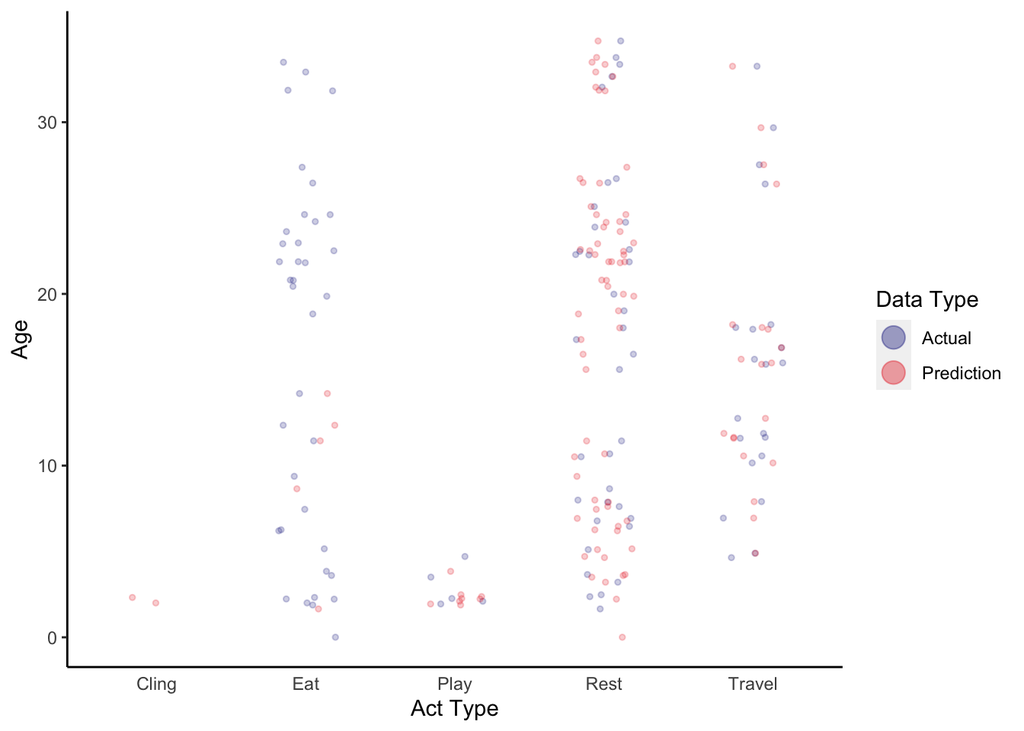

```r
> sampledf <- data.frame(Age = test_1$Age, Actual = test_1$Act, Prediction = pred_nn_1)
> sampledf <- slice_sample(sampledf, n = 100)
>
> ggplot() + geom_jitter(data = sampledf, aes(y = Age, x = Actual, color = "#000080"),
+     alpha = 0.2, width = 0.2, size = 1) + geom_jitter(data = sampledf, aes(y = Age,
+     x = Prediction, color = "#e60012"), alpha = 0.2, width = 0.2, size = 1) +
+     scale_colour_manual(values = c("#000080", "#e60012"), labels = c("Actual",
+         "Prediction"), name = "Data Type") + theme(axis.ticks.x = element_blank(),
+     panel.border = element_blank(), panel.grid.major = element_blank(), panel.grid.minor = element_blank(),
+     axis.line = element_line(colour = "black"), panel.background = element_blank()) +
+     guides(colour = guide_legend(override.aes = list(size = 5))) + ylab("Age") +
+     xlab("Act Type") + scale_size_continuous(guide = "none")
```

## MCMCglmm

```r
> model_mcmc_1 <- MCMCglmm(Act ~ Age + TP + BP, random = ~Follow + Name + Date,
+     rcov = ~us(trait):units, family = "categorical", data = knott_data, nitt = 100,
+     burnin = 10, pr = TRUE)
```

```
##
##                        MCMC iteration = 0
##
##  Acceptance ratio for liability set 1 = 0.000358
```

```r
> summary(model_mcmc_1)
```

```
##
##  Iterations = 11:91
##  Thinning interval  = 10
##  Sample size  = 9
##
##  DIC: 126648.7
##
##  G-structure:  ~Follow
##
##        post.mean l-95% CI u-95% CI eff.samp
## Follow   0.01628  0.01208  0.02006    2.421
##
##                ~Name
##
##      post.mean  l-95% CI u-95% CI eff.samp
## Name 0.0005757 0.0001853 0.001497    2.639
##
##                ~Date
##
##      post.mean l-95% CI u-95% CI eff.samp
## Date  0.008639 0.006385  0.01544        9
##
##  R-structure:  ~us(trait):units
##
##                                       post.mean l-95% CI  u-95% CI eff.samp
## traitAct.Eat:traitAct.Eat.units         1.44686  1.03372  1.987399    1.569
## traitAct.Play:traitAct.Eat.units        0.10949  0.04647  0.185726    1.824
## traitAct.Rest:traitAct.Eat.units       -0.60518 -1.35206 -0.002930    1.497
## traitAct.Travel:traitAct.Eat.units     -0.02667 -0.05311  0.039778    1.824
## traitAct.Eat:traitAct.Play.units        0.10949  0.04647  0.185726    1.824
## traitAct.Play:traitAct.Play.units       0.73665  0.56081  0.962361    1.728
## traitAct.Rest:traitAct.Play.units      -0.09250 -0.18978  0.012578    1.689
## traitAct.Travel:traitAct.Play.units     0.16247  0.04361  0.220127    2.054
## traitAct.Eat:traitAct.Rest.units       -0.60518 -1.35206 -0.002930    1.497
## traitAct.Play:traitAct.Rest.units      -0.09250 -0.18978  0.012578    1.689
## traitAct.Rest:traitAct.Rest.units       1.86731  1.11615  2.807668    1.630
## traitAct.Travel:traitAct.Rest.units    -0.31906 -0.63815 -0.003777    1.551
## traitAct.Eat:traitAct.Travel.units     -0.02667 -0.05311  0.039778    1.824
## traitAct.Play:traitAct.Travel.units     0.16247  0.04361  0.220127    2.054
## traitAct.Rest:traitAct.Travel.units    -0.31906 -0.63815 -0.003777    1.551
## traitAct.Travel:traitAct.Travel.units   1.05412  0.98420  1.194316    1.731
##
##  Location effects: Act ~ Age + TP + BP
##
##                post.mean   l-95% CI   u-95% CI eff.samp pMCMC
## (Intercept)    0.2518810  0.0423212  0.4147858    1.973  <0.1
## Age            0.0003237 -0.0007105  0.0015375    9.000 0.889
## TPCrotch      -0.0249062 -0.0471611  0.0013354    2.907 0.222
## TPGround       0.1110849 -0.0092507  0.2723300    9.000 0.222
## TPIbu         -0.8074519 -0.9383673 -0.5103191    2.056  <0.1
## TPLiana       -0.0456282 -0.0816717 -0.0208434    6.878  <0.1
## TPNest        -0.0463137 -0.0691804 -0.0306281    9.000  <0.1
## TPTrunk        0.0736847 -0.0043312  0.1055990    9.000 0.222
## BPBrachiate    0.0156748 -0.0137476  0.0566044    1.209 0.889
## BPHang        -0.0162890 -0.0373361  0.0035608    9.000 0.444
## BPLieDown      0.0230121 -0.0298792  0.0693407    5.585 0.667
## BPQuad        -0.0154637 -0.0654477  0.0124594    9.000 0.667
## BPSit          0.0049329 -0.0208253  0.0271183    9.000 0.889
## BPSlowClamber  0.0161463 -0.0183559  0.0476974    9.000 0.444
## BPTreeSway    -0.0145775 -0.0591236  0.0341048    9.000 0.889
```

```r
> model_mcmc_2 <- MCMCglmm(Act ~ Age + Age * Age + TP + BP + BP * Age + TP * BP,
+     random = ~Follow + Name + Date, rcov = ~us(trait):units, family = "categorical",
+     data = knott_data, nitt = 100, burnin = 10, pr = TRUE)
```

```
##
##                        MCMC iteration = 0
##
##  Acceptance ratio for liability set 1 = 0.000361
```

```r
> summary(model_mcmc_2)
```

```
##
##  Iterations = 11:91
##  Thinning interval  = 10
##  Sample size  = 9
##
##  DIC: 125613.9
##
##  G-structure:  ~Follow
##
##        post.mean l-95% CI u-95% CI eff.samp
## Follow   0.01863  0.01704  0.02149        9
##
##                ~Name
##
##      post.mean  l-95% CI u-95% CI eff.samp
## Name 0.0006961 7.037e-05 0.003468        9
##
##                ~Date
##
##      post.mean l-95% CI u-95% CI eff.samp
## Date  0.008844 0.006484  0.01254    2.372
##
##  R-structure:  ~us(trait):units
##
##                                       post.mean l-95% CI   u-95% CI eff.samp
## traitAct.Eat:traitAct.Eat.units         1.48581  1.04288  2.0287243    1.581
## traitAct.Play:traitAct.Eat.units        0.11034  0.04838  0.1590403    1.133
## traitAct.Rest:traitAct.Eat.units       -0.63071 -1.33921 -0.0274686    1.454
## traitAct.Travel:traitAct.Eat.units     -0.04082 -0.08929  0.0270740    2.817
## traitAct.Eat:traitAct.Play.units        0.11034  0.04838  0.1590403    1.133
## traitAct.Play:traitAct.Play.units       0.71935  0.54431  0.9440086    1.481
## traitAct.Rest:traitAct.Play.units      -0.07674 -0.15882  0.0143429    1.341
## traitAct.Travel:traitAct.Play.units     0.19234  0.07623  0.2800683    1.657
## traitAct.Eat:traitAct.Rest.units       -0.63071 -1.33921 -0.0274686    1.454
## traitAct.Play:traitAct.Rest.units      -0.07674 -0.15882  0.0143429    1.341
## traitAct.Rest:traitAct.Rest.units       1.95893  1.11663  2.9241316    1.535
## traitAct.Travel:traitAct.Rest.units    -0.30071 -0.59514 -0.0007055    1.613
## traitAct.Eat:traitAct.Travel.units     -0.04082 -0.08929  0.0270740    2.817
## traitAct.Play:traitAct.Travel.units     0.19234  0.07623  0.2800683    1.657
## traitAct.Rest:traitAct.Travel.units    -0.30071 -0.59514 -0.0007055    1.613
```

[output cut: 50 more lines]

```
## TPGround:BPSit         -0.6786766 -1.2822648  0.0770850    2.951 0.222
## TPIbu:BPSit             0.0336475 -0.2659324  0.3522047    9.000 0.889
## TPLiana:BPSit           0.0482189 -0.0354778  0.1039484    9.842 0.222
## TPNest:BPSit            0.0424553 -0.0786178  0.1862569    9.000 0.667
## TPTrunk:BPSit          -0.1796034 -0.3482284  0.0018851    2.241 0.222
## TPCrotch:BPSlowClamber  0.0256194 -0.0574360  0.0925270    9.000 0.667
## TPGround:BPSlowClamber -0.9692736 -1.2937643 -0.1262537    2.837  <0.1
## TPLiana:BPSlowClamber   0.0758383  0.0148525  0.1283823    2.012  <0.1
## TPNest:BPSlowClamber    0.7195579  0.3410161  1.1771134    2.311  <0.1
## TPTrunk:BPSlowClamber  -0.2450237 -0.4441889  0.0320038    1.411 0.444
## TPCrotch:BPTreeSway    -0.2550718 -0.6629295  0.2175236    9.000 0.667
## TPGround:BPTreeSway    -2.8265359 -4.7827083  0.4738475    2.704 0.222
## TPLiana:BPTreeSway      0.9724442  0.0024735  1.7900892    1.341  <0.1
## TPNest:BPTreeSway      -2.1518496 -3.5861142  0.4447906    2.353 0.222
## TPTrunk:BPTreeSway      0.1446561 -0.0111802  0.3834863    9.000 0.222
```

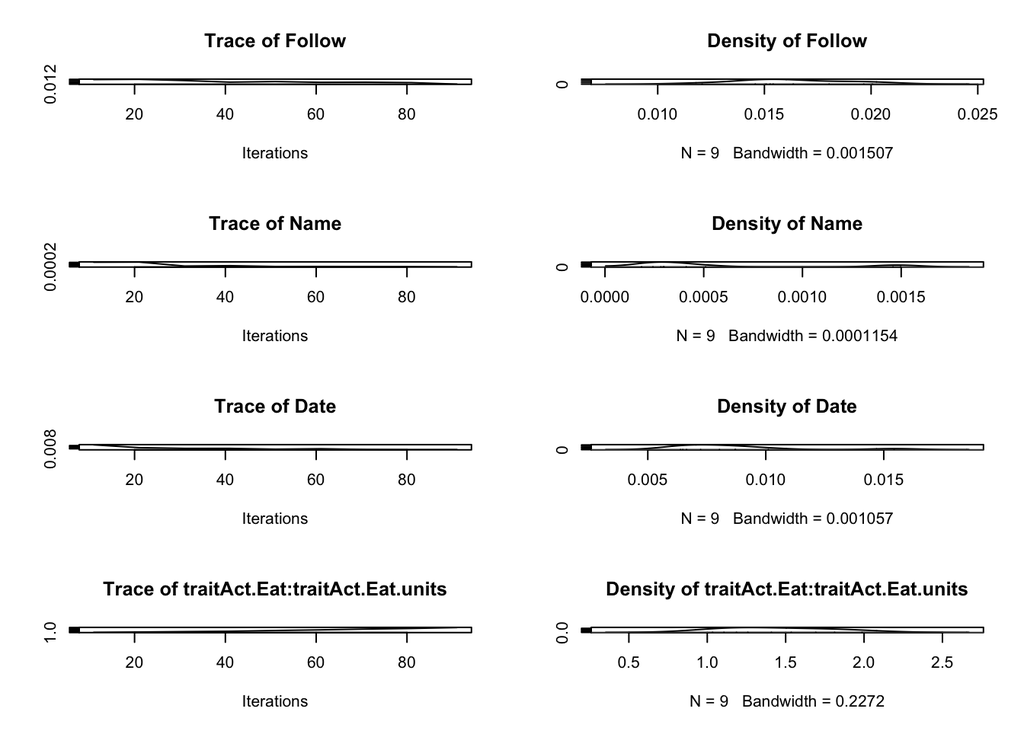

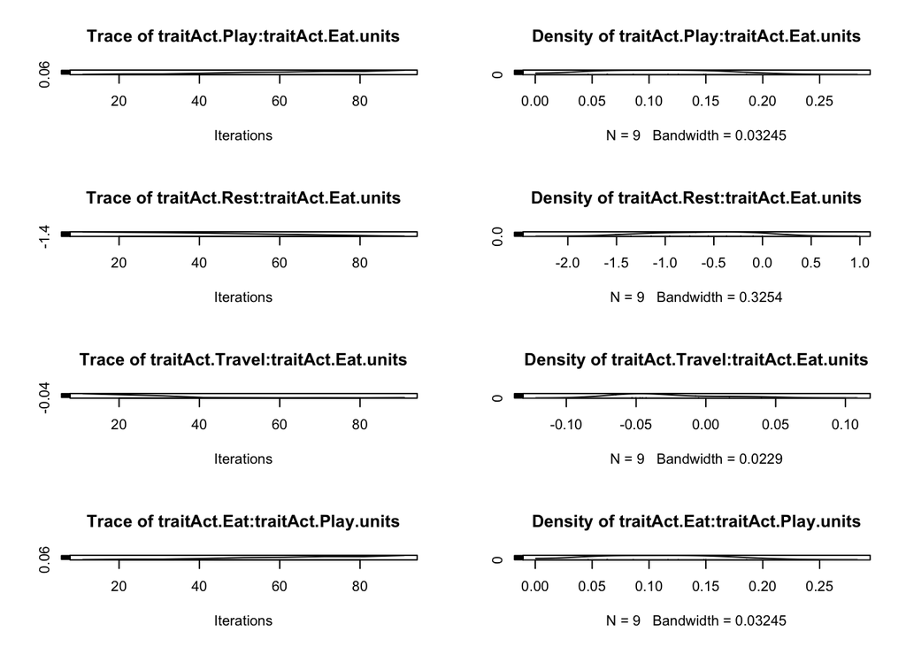

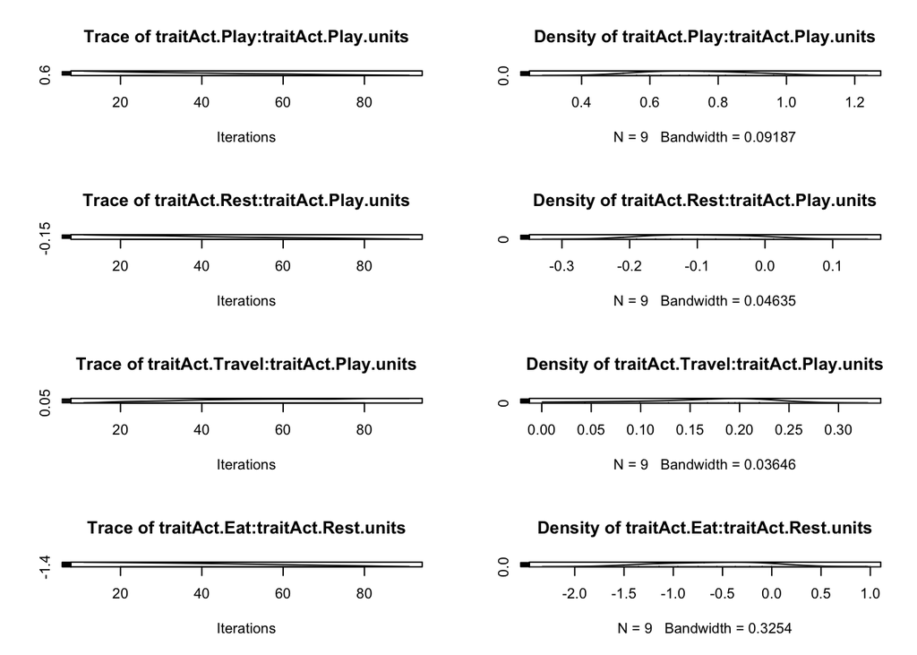

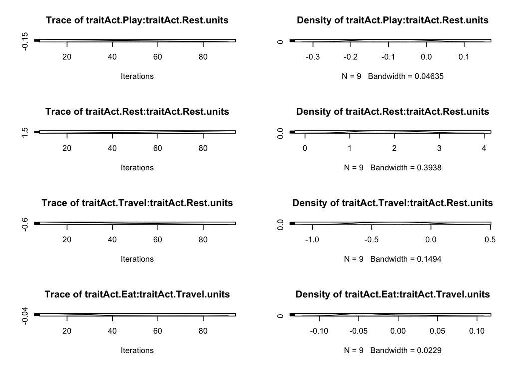

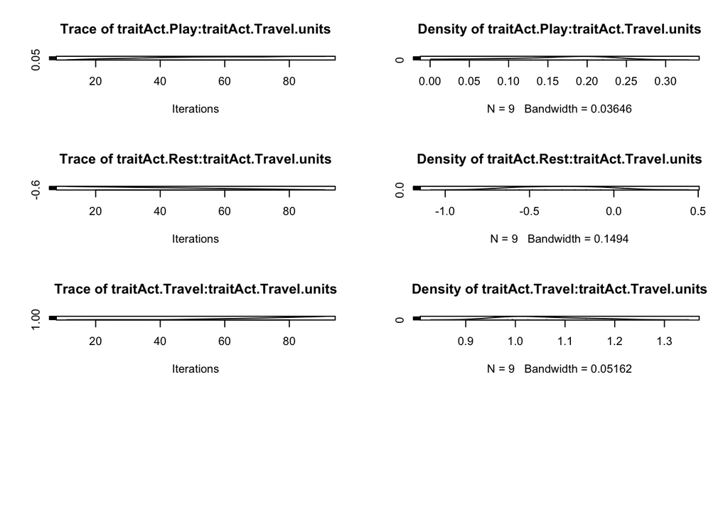

```r
> par(mfrow = c(1, 1))
> # lets see if our models are good!
> plot(model_mcmc_1$VCV)
```

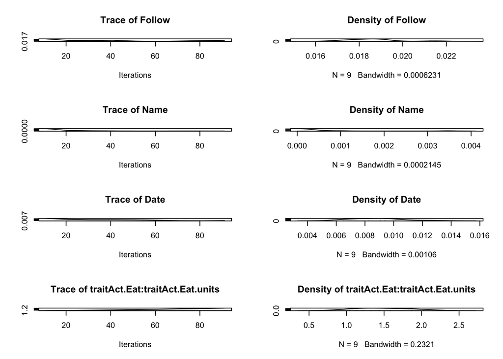

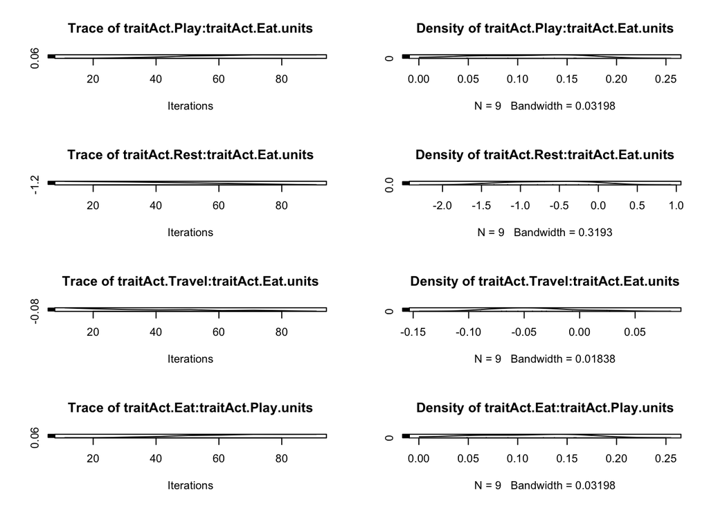

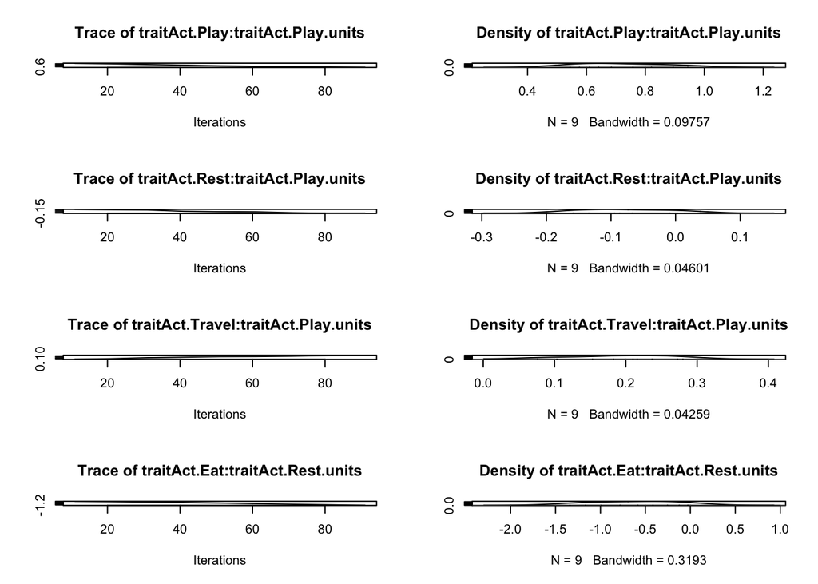

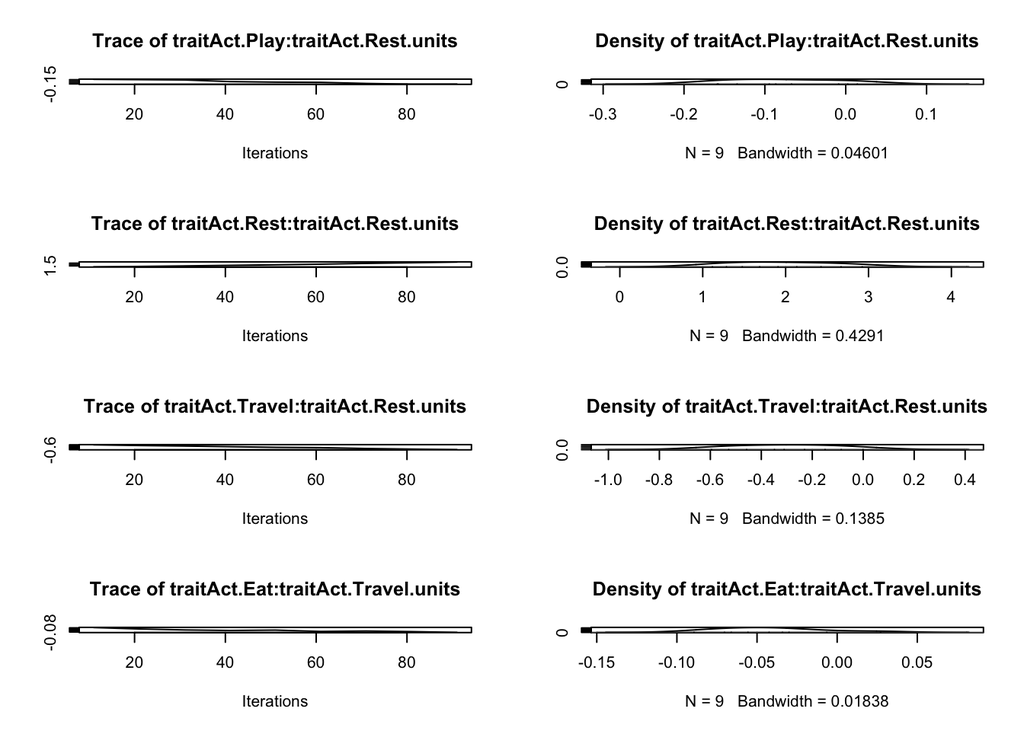

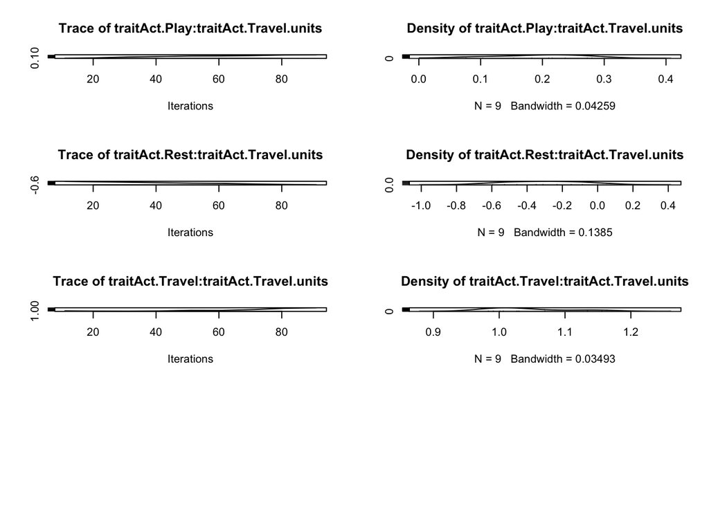

```r
> plot(model_mcmc_2$VCV)
```

```r
> df <- data.frame(model = c("Model 1", "Model 2"), DIC = c(model_mcmc_1$DIC,
+     model_mcmc_2$DIC))
> knitr::kable(df, format = "html", caption = "MCMCglmm Models")
```

MCMCglmm Models

| model | DIC |
| --- | --- |
| Model 1 | 126648.7 |
| Model 2 | 125613.9 |

The things to look out for here are 1) whether our models are mixed. This should look like a ‘caterpillar’ with a distinct middle line, in our plots. 2) the DIC value (which will be lower for better models).

# Conclusion